## **Where Complexity Meets Clarity: Navigating Bayesian, Multistate Models, and R with Ease**

By Powell Kafwanka

In this insightful interview, I had the privilege of speaking with **Dr. Isaac Fwemba**, a leading expert in Bayesian statistics and Biostatistics. Dr. Fwemba lectures at the University of Zambia’s Schools of Medicine and Public Health and is a distinguished member of the International Society for Bayesian Analysis, the International Conference for Clinical Biostatistics, and the John Hopkins Infectious Dynamic Disease Modelling Group.

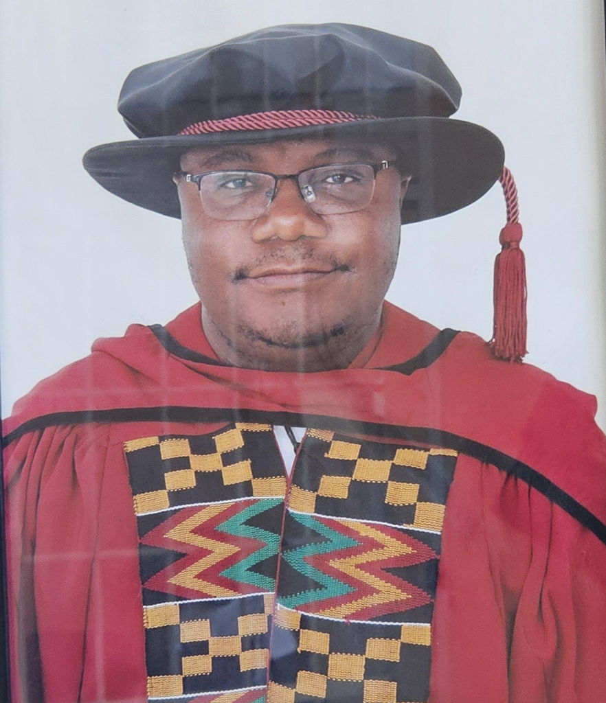

Dr. Isaac Fwemba

### **From Agro-forestry to Biostatistics: Dr. Fwemba’s Journey**

#### **Q: Can you briefly tell me about yourself and your career path to where you are today?**

Isaac’s journey into biostatistics is both unique and inspiring. He initially trained as an Agro-forester at Copperbelt University before pursuing a Master of Public Health at Manchester Metropolitan University. His passion for numbers ultimately led him to a PhD in Biostatistics with a specialization in Bayesian methods at the University of Ghana. His doctoral journey was particularly challenging, as he competed against numerous candidates globally for one of just five prestigious PhD scholarship slots across seven institutions. Securing one of these coveted positions at the University of Ghana speaks volumes about his dedication and ability.

### **Demystifying Complex Data: Bayesian Statistics, Multistate Models, and R**

#### **Q: How have you managed to demystify Bayesian Statistics, Multistate Models, and R Proficiency with such ease?**

Isaac emphasizes that **Bayesian statistics** is pivotal for advancing public health, especially in infectious disease control. He clarifies its core concept:

*“Learning from current data and prior information to make more informed future predictions.”*

This approach allows for continuous updating of estimates, offering a more dynamic and realistic understanding of disease dynamics compared to traditional statistical methods. He highlights its particular utility in situations with smaller sample sizes, where Bayesian methods can still provide reliable estimates crucial for decision-making.

His work with complex diseases like malaria and HIV inherently relies on these sophisticated tools. The seamless integration of Bayesian statistics and Multistate Modeling, coupled with **R software proficiency**, underscores its importance as a practical tool for implementing these powerful statistical methods.

### **Critical Skills in the Fight against Infectious Diseases**

#### **Q: How crucial are these skills in controlling and eliminating infectious diseases like HIV and malaria?**

Isaac highlights several reasons why these skills are indispensable in the fight against infectious diseases:

· **Informing Policy and Intervention Strategies:** By incorporating existing knowledge and continuously updating with new data, Bayesian analyses provide more robust evidence for public health policy decisions. This includes crucial aspects like resource allocation for prevention programs, drug distribution, or vaccination campaigns. He reiterates that in many infectious disease contexts, particularly in low-resource settings, data can be sparse. Bayesian methods excel here, providing reliable estimates even with limited data by expertly leveraging prior information.

· **Predicting Future Outbreaks and Trends:** The “updating and winning” aspect of Bayesian inference enables more accurate predictions of future disease incidence and prevalence, facilitating proactive public health responses.

· **Multistate Models:** Isaac stresses that **multistate models** are fundamental to understanding chronic infectious diseases with varying stages. For HIV, they are essential for modeling disease progression from infection to AIDS and different treatment outcomes. For malaria, they can track infection, treatment, re-infection, and resistance. These models provide comprehensive disease mapping, allowing researchers and public health officials to chart the transitions between different health states. Ultimately, they offer a holistic view of a disease’s natural history and the profound impact of interventions.

· **R Proficiency:** As a powerful, open-source statistical programming language, **R is indispensable** for implementing complex statistical models. Both Bayesian methods and multistate models often require sophisticated computational approaches that are readily executable in R. Its robust capabilities for data manipulation, analysis, and creating compelling visualizations are vital for understanding disease patterns, effectively communicating findings, and monitoring the impact of control efforts.

· **Reproducible Research:** **R software, coupled with GitHub**, facilitates reproducible research—a cornerstone of rigorous scientific inquiry in public health. This ensures that analyses can be readily verified and built upon by others, fostering transparency and collaboration.

In essence, Isaac underscores that these statistical and computational skills are not just theoretical concepts; they are **practical tools that underpin evidence-based decision-making** in the ongoing fight against infectious diseases.

### **Pursuing Expertise: Dr. Fwemba’s Advice**

#### **Q: Lastly, what is your advice to someone interested in attaining such skills?**

Dr. Isaac Fwemba strongly advises individuals interested in biostatistics, particularly Bayesian methods, to pursue their interest with unwavering commitment. He emphasizes that the field currently has **few experts**, offering ample opportunities for those who are dedicated. He highlights that top universities across Africa are actively seeking individuals with these highly sought-after skills. He firmly believes that with dedication and collaboration, one can achieve significant success in the field, regardless of their background or location.